# Pràctica 2

mtp1268

14/12/2021

## 1 Descripció del dataset

Es carrega el dataset al programa R:

Es mostra el resum del dataset que s’ha carregat

```r
summary(titanic_original)
```

```
##   PassengerId       Survived          Pclass          Name
##  Min.   :  1.0   Min.   :0.0000   Min.   :1.000   Length:891
##  1st Qu.:223.5   1st Qu.:0.0000   1st Qu.:2.000   Class :character
##  Median :446.0   Median :0.0000   Median :3.000   Mode  :character
##  Mean   :446.0   Mean   :0.3838   Mean   :2.309
##  3rd Qu.:668.5   3rd Qu.:1.0000   3rd Qu.:3.000
##  Max.   :891.0   Max.   :1.0000   Max.   :3.000
##
##      Sex                 Age            SibSp           Parch
##  Length:891         Min.   : 0.42   Min.   :0.000   Min.   :0.0000
##  Class :character   1st Qu.:20.12   1st Qu.:0.000   1st Qu.:0.0000
##  Mode  :character   Median :28.00   Median :0.000   Median :0.0000
##                     Mean   :29.70   Mean   :0.523   Mean   :0.3816
##                     3rd Qu.:38.00   3rd Qu.:1.000   3rd Qu.:0.0000
##                     Max.   :80.00   Max.   :8.000   Max.   :6.0000
##                     NA's   :177
##     Ticket               Fare           Cabin             Embarked
##  Length:891         Min.   :  0.00   Length:891         Length:891
##  Class :character   1st Qu.:  7.91   Class :character   Class :character
##  Mode  :character   Median : 14.45   Mode  :character   Mode  :character
##                     Mean   : 32.20
##                     3rd Qu.: 31.00
##                     Max.   :512.33
##
```

```r
str(titanic_original)
```

```
## spec_tbl_df [891 x 12] (S3: spec_tbl_df/tbl_df/tbl/data.frame)
##  $ PassengerId: num [1:891] 1 2 3 4 5 6 7 8 9 10 ...
##  $ Survived   : num [1:891] 0 1 1 1 0 0 0 0 1 1 ...
##  $ Pclass     : num [1:891] 3 1 3 1 3 3 1 3 3 2 ...
##  $ Name       : chr [1:891] "Braund, Mr. Owen Harris" "Cumings, Mrs. John Bradley (Florence Briggs Thayer)" "Heikkinen, Miss. Laina" "Futrelle, Mrs. Jacques Heath (Lily May Peel)" ...
##  $ Sex        : chr [1:891] "male" "female" "female" "female" ...
##  $ Age        : num [1:891] 22 38 26 35 35 NA 54 2 27 14 ...
##  $ SibSp      : num [1:891] 1 1 0 1 0 0 0 3 0 1 ...
##  $ Parch      : num [1:891] 0 0 0 0 0 0 0 1 2 0 ...
##  $ Ticket     : chr [1:891] "A/5 21171" "PC 17599" "STON/O2. 3101282" "113803" ...
##  $ Fare       : num [1:891] 7.25 71.28 7.92 53.1 8.05 ...
##  $ Cabin      : chr [1:891] NA "C85" NA "C123" ...
##  $ Embarked   : chr [1:891] "S" "C" "S" "S" ...
##  - attr(*, "spec")=
##   .. cols(
##   ..   PassengerId = col_double(),
##   ..   Survived = col_double(),
##   ..   Pclass = col_double(),
##   ..   Name = col_character(),
##   ..   Sex = col_character(),
##   ..   Age = col_double(),
##   ..   SibSp = col_double(),
##   ..   Parch = col_double(),
##   ..   Ticket = col_character(),
##   ..   Fare = col_double(),
##   ..   Cabin = col_character(),
##   ..   Embarked = col_character()
##   .. )
##  - attr(*, "problems")=<externalptr>
```

```r
head(titanic_original)
```

```
## # A tibble: 6 x 12
##   PassengerId Survived Pclass Name    Sex     Age SibSp Parch Ticket  Fare Cabin
##         <dbl>    <dbl>  <dbl> <chr>   <chr> <dbl> <dbl> <dbl> <chr>  <dbl> <chr>
## 1           1        0      3 Braund~ male     22     1     0 A/5 2~  7.25 <NA>
## 2           2        1      1 Cuming~ fema~    38     1     0 PC 17~ 71.3  C85
## 3           3        1      3 Heikki~ fema~    26     0     0 STON/~  7.92 <NA>
## 4           4        1      1 Futrel~ fema~    35     1     0 113803 53.1  C123
## 5           5        0      3 Allen,~ male     35     0     0 373450  8.05 <NA>
## 6           6        0      3 Moran,~ male     NA     0     0 330877  8.46 <NA>
## # ... with 1 more variable: Embarked <chr>
```

## 2 Integració i selecció de les dades d’interès a analitzar

Es recupera els noms de les variables perque s’eliminaran les que no descriuen a les persones ni al tipus de bitllet:

```r
names(titanic_original)
```

```
##  [1] "PassengerId" "Survived"    "Pclass"      "Name"        "Sex"
##  [6] "Age"         "SibSp"       "Parch"       "Ticket"      "Fare"
## [11] "Cabin"       "Embarked"
```

Per tant les variables que es poden eliminar del dataset son: Name, ticket, fare, cabin

```r
titanic <- titanic_original[,-c(4,9,10,11)]
```

Es prepara una variable categoria per a tenir agrupat els passatges que son menors, del 18 al 60 i mes grans que 60 per a tenir la variable creada per a un futur analisis.

```r
titanic["group_age"] <- cut(titanic$Age, breaks = c(-1,17,60,Inf), labels = c("menors", "18-60", ">60"), include.lowest = TRUE)
```

## 3 Neteja de les dades

Es comprova els valors unics per a cada variable:

```r
head(unique(titanic$PassengerId))
```

```
## [1] 1 2 3 4 5 6
```

```r
unique(titanic$Survived)
```

```
## [1] 0 1
```

```r
unique(titanic$Pclass)
```

```
## [1] 3 1 2
```

```r
unique(titanic$Sex)
```

```
## [1] "male"   "female"
```

```r
unique(titanic$Age)
```

```
##  [1] 22.00 38.00 26.00 35.00    NA 54.00  2.00 27.00 14.00  4.00 58.00 20.00
## [13] 39.00 55.00 31.00 34.00 15.00 28.00  8.00 19.00 40.00 66.00 42.00 21.00
## [25] 18.00  3.00  7.00 49.00 29.00 65.00 28.50  5.00 11.00 45.00 17.00 32.00
## [37] 16.00 25.00  0.83 30.00 33.00 23.00 24.00 46.00 59.00 71.00 37.00 47.00
## [49] 14.50 70.50 32.50 12.00  9.00 36.50 51.00 55.50 40.50 44.00  1.00 61.00
## [61] 56.00 50.00 36.00 45.50 20.50 62.00 41.00 52.00 63.00 23.50  0.92 43.00
## [73] 60.00 10.00 64.00 13.00 48.00  0.75 53.00 57.00 80.00 70.00 24.50  6.00
## [85]  0.67 30.50  0.42 34.50 74.00
```

```r
unique(titanic$SibSp)
```

```
## [1] 1 0 3 4 2 5 8
```

```r
unique(titanic$Parch)
```

```
## [1] 0 1 2 5 3 4 6
```

```r
unique(titanic$Embarked)
```

```
## [1] "S" "C" "Q" NA
```

A simple vista es veu que els valors son adequats, s’ha detectat alguns valors nulls es mira a quines variables hi ha mes casos:

```r
colSums(is.na(titanic))
```

```
## PassengerId    Survived      Pclass         Sex         Age       SibSp
##           0           0           0           0         177           0
##       Parch    Embarked   group_age
##           0           2         177
```

### 3.1 Les dades contenen zeros o elements buits? Com gestionaries aquests casos?

Com es pot identificar hi ha les variables **age i embarked que tenen valors nulls**, com que tenim informació suficient es pot calcular amb algun algoritme de clusters per identificar qui valor pot tenir l’edat, en aquest cas es realitzara amb el KNN i es tindra en compte el sexe del passatger:

```r
library(class)
titanic.knn <- na.omit(titanic)
titanic.knn$Embarked <- as.numeric(as.factor(titanic.knn$Embarked))

predict_age_for_sex_passenger <- function(subset){
  rows <- sample(1:nrow(subset), 0.8*nrow(subset))
  train <- subset[rows,]
  test <- subset[-rows,]
  model <- knn(train, test ,train$Age)

  result <- table(model)
  return(as.integer(names(result[result==max(result)])) )
}

#Male
titanic.knn.male <- titanic.knn[titanic.knn$Sex == "male",c(1,2,3,5,6,7)]
age.male <- mean(predict_age_for_sex_passenger(titanic.knn.male))


#Female
titanic.knn.female <- titanic.knn[titanic.knn$Sex == "female",c(1,2,3,5,6,7)]
age.female <- mean(predict_age_for_sex_passenger(titanic.knn.female))
```

Amb els valors que ha predit l’algorisme es procedeix a informar al dataset de titanic:

```r
table(is.na(titanic$Age))
```

```
##
## FALSE  TRUE
##   714   177
```

```r
titanic[titanic$Sex =="male" & is.na(titanic$Age),]$Age <- age.male

titanic[titanic$Sex =="female" & is.na(titanic$Age),]$Age <- age.female

table(is.na(titanic$Age))
```

```
##
## FALSE
##   891
```

Pel cas de **la variable Embarked**, es procedira a buscar quin es el valor que mes es repeteix per a informar les observacions que tenen un valor null:

```r
table(titanic$Embarked)
```

```
##
##   C   Q   S
## 168  77 644
```

Com es pot veure el resultat es S

```r
titanic[is.na(titanic$Embarked),]$Embarked <- "S"
```

Es categoritza la variable Embarked a númerica on:

- S per 1
- C per 2
- Q per 3

```r
titanic["Embarked_cat"] <- 3

titanic[titanic$Embarked == "S",]$Embarked_cat <- 1

titanic[titanic$Embarked == "C",]$Embarked_cat <- 2
```

### 3.2 Identificació i tractament de valors extrems.

Per a la revisió de outliers es revisaran a les variables numeriques continues com: Age, SibSp i Parch, ja que la resta de variables estan categoritzades i per tant tenen un rang definit.

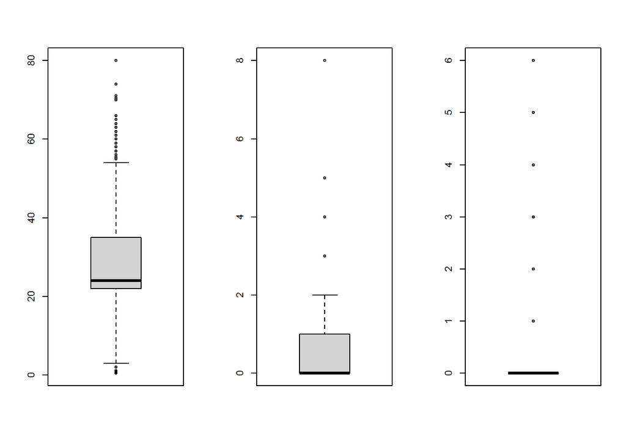

```r
par(mfrow=c(1,3))
outliers.age <- boxplot(titanic$Age)
outliers.sib <- boxplot(titanic$SibSp)
outliers.par <- boxplot(titanic$Parch)
```

```r
par(mfrow=c(1,1))
```

Es pot veure que en cada variable hi ha algun valor fora del normal i per tant es revisa quins son:

```r
outliers.age$out
```

```
##  [1]  2.00 58.00 55.00  2.00 66.00 65.00  0.83 59.00 71.00 70.50  2.00 55.50
## [13]  1.00 61.00  1.00 56.00  1.00 58.00  2.00 59.00 62.00 58.00 63.00 65.00
## [25]  2.00  0.92 61.00  2.00 60.00  1.00  1.00 64.00 65.00 56.00  0.75  2.00
## [37] 63.00 58.00 55.00 71.00  2.00 64.00 62.00 62.00 60.00 61.00 57.00 80.00
## [49]  2.00  0.75 56.00 58.00 70.00 60.00 60.00 70.00  0.67 57.00  1.00  0.42
## [61]  2.00  1.00 62.00  0.83 74.00 56.00
```

```r
outliers.sib$out
```

```
##  [1] 3 4 3 3 4 5 3 4 5 3 3 4 8 4 4 3 8 4 8 3 4 4 4 4 8 3 3 5 3 5 3 4 4 3 3 5 4 3
## [39] 4 8 4 3 4 8 4 8
```

```r
outliers.par$out
```

```
##   [1] 1 2 1 5 1 1 5 2 2 1 1 2 2 2 1 2 2 2 3 2 2 1 1 1 1 2 1 1 2 2 1 2 2 2 1 2 1
##  [38] 1 2 1 4 1 1 1 1 2 2 1 2 1 1 1 2 1 1 2 2 2 1 1 2 2 1 2 1 1 1 1 1 1 1 2 1 2
##  [75] 2 1 1 2 1 1 2 1 1 1 1 2 1 1 1 4 1 1 2 2 2 2 2 1 1 1 2 2 1 1 2 2 3 4 1 2 1
## [112] 1 2 1 2 1 2 1 1 2 2 1 1 1 1 2 2 2 2 2 2 1 1 2 1 4 1 1 2 1 2 1 1 2 5 2 1 1
## [149] 1 2 1 5 2 1 1 1 2 1 6 1 2 1 2 1 1 1 1 1 1 1 3 2 1 1 1 1 2 1 2 3 1 2 1 2 2
## [186] 1 1 2 1 2 1 2 1 1 1 2 1 1 2 1 2 1 1 1 1 3 2 1 1 1 1 5 2
```

Amb els valors outliers anteriors pot haver casos que les persones siguin molt grans o molt petites igual que poder viatgin soles o amb familia i que per tant aquests registres no s’haurien de omitir ja que es tindran en compte els passatger amb aquestes característiques.

## 4 Anàlisi de les dades

Avanç de generar el CSV amb les dades netejades, al haver treballat la variable Edat amb els valors nulls s’ha de tornar a procesar l’agrupació per edat:

```r
titanic["group_age"] <- cut(titanic$Age, breaks = c(-1,17,60,Inf), labels = c("menors", "18-60", ">60"), include.lowest = TRUE)
```

Tal com es comenta a l’enunciat es vol tenir el dataset netejat, per tant es crea el fitxer titanit_clean.csv

```r
write.csv(titanic,"../docs/titanic_clean.csv",row.names = FALSE)
```

### 4.1 Selecció dels grups de dades que es volen analitzar/comparar

Es vol estudiar els grups d’edat que han sobreviscut i els que no:

```r
titanic.survived <- titanic[titanic$Survived == 1,]

titanic.no.survived <- titanic[titanic$Survived == 0,]
```

### 4.2 Comprovació de la normalitat i homogeneïtat de la variància

Per a la comprovació de normalitat es realitzara amb el test de Kolmogorov-Smirnov dels dos grups creats anteriorment:

```r
y <- pnorm

ks.test(titanic.survived$Age, y, mean(titanic.survived$Age), sd(titanic.survived$Age))
```

```
##
##  One-sample Kolmogorov-Smirnov test
##
## data:  titanic.survived$Age
## D = 0.095945, p-value = 0.003685
## alternative hypothesis: two-sided
```

```r
ks.test(titanic.no.survived$Age, y, mean(titanic.no.survived$Age), sd(titanic.no.survived$Age))
```

```
##
##  One-sample Kolmogorov-Smirnov test
##
## data:  titanic.no.survived$Age
## D = 0.16232, p-value = 5.459e-13
## alternative hypothesis: two-sided
```

Igual que pasa amb el dataset anterior, la distribució no es normal ja que te un valor mes petit que 0.05.

**Nota:** *Per calcular la normalitat s’ha tret de la documentació a l’apartat de Comprovació de la normalitat del temari de Introducció a la neteja de dades*

### 4.3 Aplicació de proves estadístiques per comparar els grups de dades

> En funció de les dades i de l’objectiu de l’estudi, aplicar proves de contrast d’hipòtesis, correlacions, regressions, etc. Aplicar almenys tres mètodes d’anàlisi diferents.

```r
library(corrplot)
c <- cor(titanic.survived[,c("Survived","Pclass","Age", "SibSp", "Parch", "Embarked_cat")])
c
```

```
##              Survived      Pclass         Age       SibSp       Parch
## Survived            1          NA          NA          NA          NA
## Pclass             NA  1.00000000 -0.39957650 -0.03329960  0.02158367
## Age                NA -0.39957650  1.00000000 -0.12462416 -0.27258717
## SibSp              NA -0.03329960 -0.12462416  1.00000000  0.28249844
## Parch              NA  0.02158367 -0.27258717  0.28249844  1.00000000
## Embarked_cat       NA  0.13358784 -0.07483924 -0.05385516 -0.17002727
##              Embarked_cat
## Survived               NA
## Pclass         0.13358784
## Age           -0.07483924
## SibSp         -0.05385516
## Parch         -0.17002727
## Embarked_cat   1.00000000
```

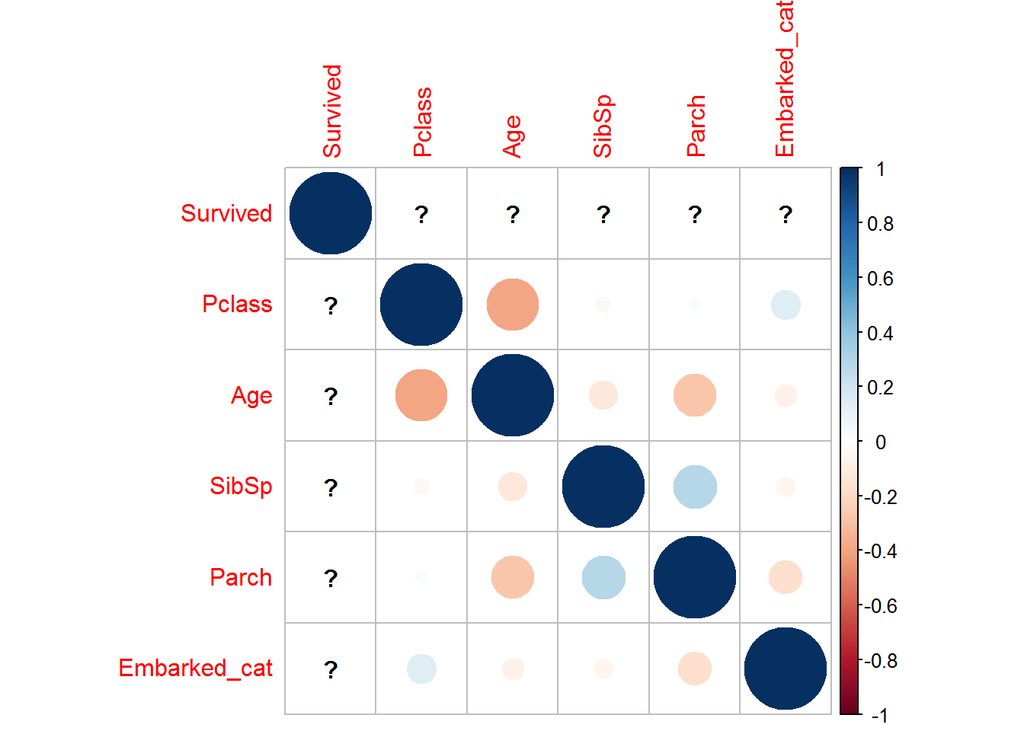

```r
corrplot(c)
```

Es prova amb un altre model a veure si ens dona mes informació sobre les relacions de Survived.

```r
summary(lm(Survived ~ Pclass, data = titanic))
```

```
##
## Call:
## lm(formula = Survived ~ Pclass, data = titanic)
##
## Residuals:
##     Min      1Q  Median      3Q     Max
## -0.6416 -0.2476 -0.2476  0.3584  0.7524
##
## Coefficients:
##             Estimate Std. Error t value Pr(>|t|)
## (Intercept)  0.83863    0.04510   18.60   <2e-16 ***
## Pclass      -0.19700    0.01837  -10.72   <2e-16 ***
## ---
## Signif. codes:  0 '***' 0.001 '**' 0.01 '*' 0.05 '.' 0.1 ' ' 1
##
## Residual standard error: 0.4581 on 889 degrees of freedom
## Multiple R-squared:  0.1146, Adjusted R-squared:  0.1136
## F-statistic:   115 on 1 and 889 DF,  p-value: < 2.2e-16
```

```r
summary(lm(Survived ~ Sex, data = titanic))
```

```
##
## Call:
## lm(formula = Survived ~ Sex, data = titanic)
##
## Residuals:
##     Min      1Q  Median      3Q     Max
## -0.7420 -0.1889 -0.1889  0.2580  0.8111
##
## Coefficients:
##             Estimate Std. Error t value Pr(>|t|)
## (Intercept)  0.74204    0.02307   32.17   <2e-16 ***
## Sexmale     -0.55313    0.02866  -19.30   <2e-16 ***
## ---
## Signif. codes:  0 '***' 0.001 '**' 0.01 '*' 0.05 '.' 0.1 ' ' 1
##
## Residual standard error: 0.4087 on 889 degrees of freedom
## Multiple R-squared:  0.2952, Adjusted R-squared:  0.2944
## F-statistic: 372.4 on 1 and 889 DF,  p-value: < 2.2e-16
```

```r
summary(lm(Survived ~ Age, data = titanic))
```

```
##
## Call:
## lm(formula = Survived ~ Age, data = titanic)
##
## Residuals:
##     Min      1Q  Median      3Q     Max
## -0.4277 -0.3939 -0.3665  0.6078  0.6995
##
## Coefficients:
##              Estimate Std. Error t value Pr(>|t|)
## (Intercept)  0.429269   0.038167  11.247   <2e-16 ***
## Age         -0.001609   0.001223  -1.316    0.188
## ---
## Signif. codes:  0 '***' 0.001 '**' 0.01 '*' 0.05 '.' 0.1 ' ' 1
##
## Residual standard error: 0.4864 on 889 degrees of freedom
## Multiple R-squared:  0.001945,   Adjusted R-squared:  0.0008225
## F-statistic: 1.733 on 1 and 889 DF,  p-value: 0.1884
```

```r
summary(lm(Survived ~ SibSp, data = titanic))
```

```
##
## Call:
## lm(formula = Survived ~ SibSp, data = titanic)
##
## Residuals:
##     Min      1Q  Median      3Q     Max
## -0.3920 -0.3920 -0.3764  0.6080  0.6704
##
## Coefficients:
##             Estimate Std. Error t value Pr(>|t|)
## (Intercept)  0.39199    0.01804  21.726   <2e-16 ***
## SibSp       -0.01559    0.01479  -1.054    0.292
## ---
## Signif. codes:  0 '***' 0.001 '**' 0.01 '*' 0.05 '.' 0.1 ' ' 1
##
## Residual standard error: 0.4866 on 889 degrees of freedom
## Multiple R-squared:  0.001248,   Adjusted R-squared:  0.0001242
## F-statistic: 1.111 on 1 and 889 DF,  p-value: 0.2922
```

```r
summary(lm(Survived ~ Parch , data = titanic))
```

```
##
## Call:
## lm(formula = Survived ~ Parch, data = titanic)
##
## Residuals:
##     Min      1Q  Median      3Q     Max
## -0.6607 -0.3650 -0.3650  0.6350  0.6350
##
## Coefficients:
##             Estimate Std. Error t value Pr(>|t|)
## (Intercept)  0.36503    0.01799  20.294   <2e-16 ***
## Parch        0.04928    0.02018   2.442   0.0148 *
## ---
## Signif. codes:  0 '***' 0.001 '**' 0.01 '*' 0.05 '.' 0.1 ' ' 1
##
## Residual standard error: 0.4852 on 889 degrees of freedom
## Multiple R-squared:  0.006663,   Adjusted R-squared:  0.005546
## F-statistic: 5.963 on 1 and 889 DF,  p-value: 0.0148
```

```r
summary(lm(Survived ~ Embarked_cat, data = titanic))
```

```
##
## Call:
## lm(formula = Survived ~ Embarked_cat, data = titanic)
##
## Residuals:
##     Min      1Q  Median      3Q     Max
## -0.5178 -0.3543 -0.3543  0.5639  0.6457
##
## Coefficients:
##              Estimate Std. Error t value Pr(>|t|)
## (Intercept)   0.27253    0.03835   7.107 2.44e-12 ***
## Embarked_cat  0.08176    0.02553   3.203  0.00141 **
## ---
## Signif. codes:  0 '***' 0.001 '**' 0.01 '*' 0.05 '.' 0.1 ' ' 1
##
## Residual standard error: 0.4841 on 889 degrees of freedom
## Multiple R-squared:  0.01141,    Adjusted R-squared:  0.0103
## F-statistic: 10.26 on 1 and 889 DF,  p-value: 0.001408
```

Es prepara una taula amb el resum de cada variable:

[output not shown]

Com es pot veure les variables que mes influeixen per sobreviure **es el sexe i el tipus de classe del bitllet**, en canvi, l’edat dels passatgers no te gairebe cap relació amb sobreviure.

Ara es comproba entre els dos grups si els que sobreviuen son els mes joves, per aixo es prova amb la hipotesi nul.la i alternativa, generant avanç la grafica de correlacions:

```r
cn <- cor(titanic.no.survived[,c("Survived","Pclass","Age", "SibSp", "Parch", "Embarked_cat")])
```

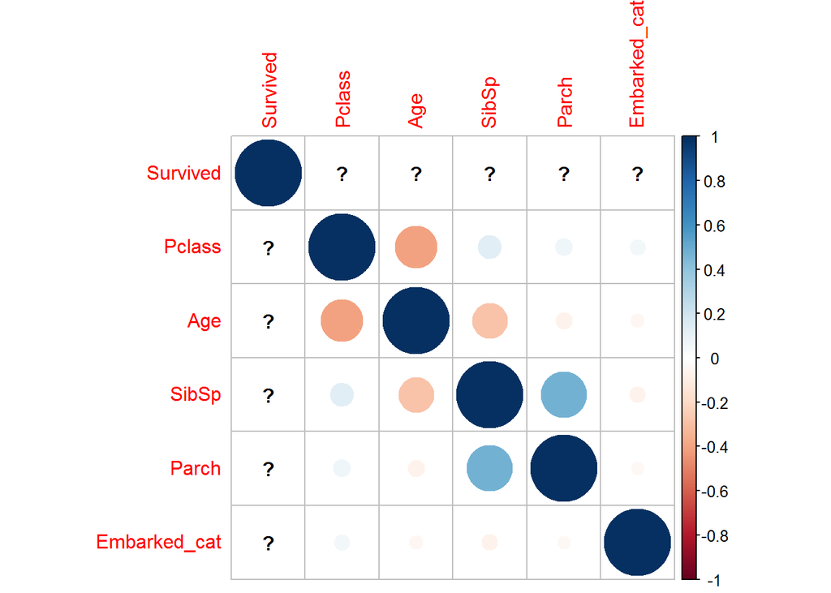

```r
corrplot(cn)
```

Les hipotesis que es vol estudiar son les següents:

H0: μs <= μk

H1: μs > μk

Com s’ha analitzat al punt anterior la variable de Age no te una distribució normal, donat que cada grup es major que 30 observacions es pot conciderar que el t-test sera suficientment robust:

```r
t.test(titanic.survived$Age,titanic.no.survived$Age,alternative="greater", var.equal=FALSE)
```

```
##
##  Welch Two Sample t-test
##
## data:  titanic.survived$Age and titanic.no.survived$Age
## t = -1.2946, df = 684.4, p-value = 0.902
## alternative hypothesis: true difference in means is greater than 0
## 95 percent confidence interval:
##  -2.746438       Inf
## sample estimates:
## mean of x mean of y
##  27.48442  28.69308
```

Com es pot veure el pvalue es superior al 0.05 i per tant s’accepta la hipotesis nul.la amb el resultat que la mitjana de edat dels sobrevivents es la mes jove o de la mateixa edat.

*Per la realització d’aquest ultim s’ha tret la informació de la seguent pagina web: https://www.cienciadedatos.net/documentos/12_t-test*

## 5 Representació dels resultats a partir de taules i gràfiques

Com s’ha mostrat anteriorment les correlacions que hi ha entre les variables dels passatger supervivents es representa gràficament:

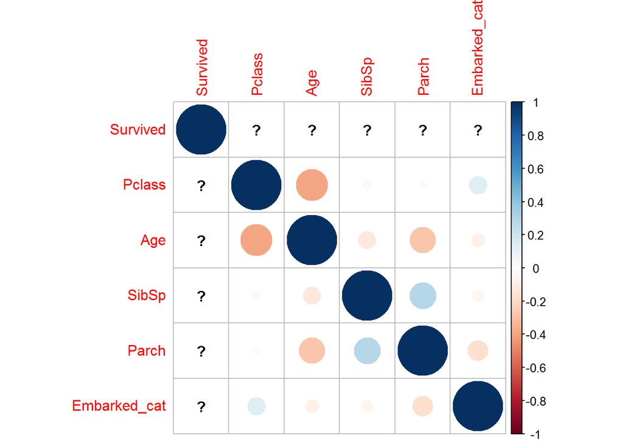

```r
corrplot(c)
```

```r
cn <- cor(titanic.no.survived[,c("Survived","Pclass","Age", "SibSp", "Parch", "Embarked_cat")])
```

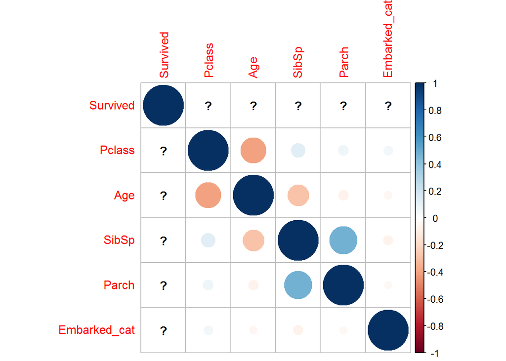

```r
corrplot(cn)
```

També per a comprovar si l’edat te una distribució normal es pot realitzar per un histograma o un gràfic de densitat:

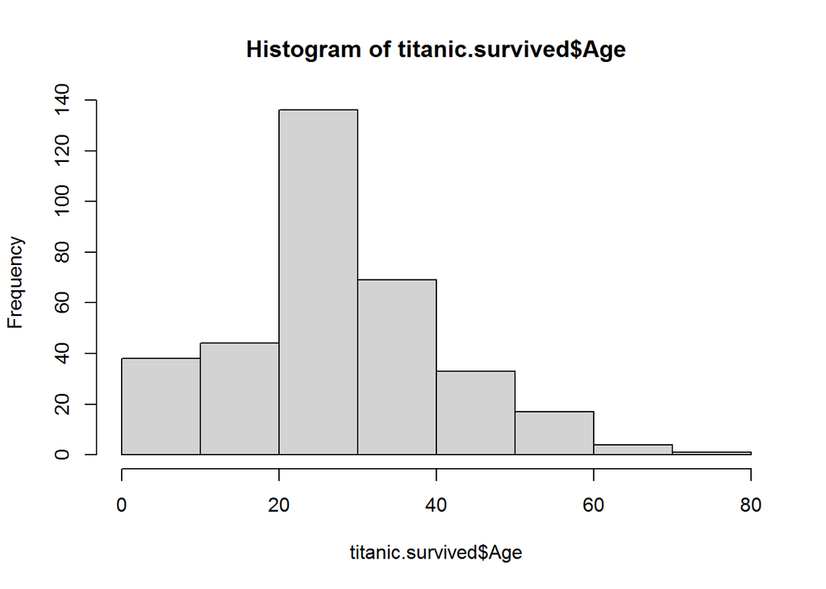

```r
hist(titanic.survived$Age)
```

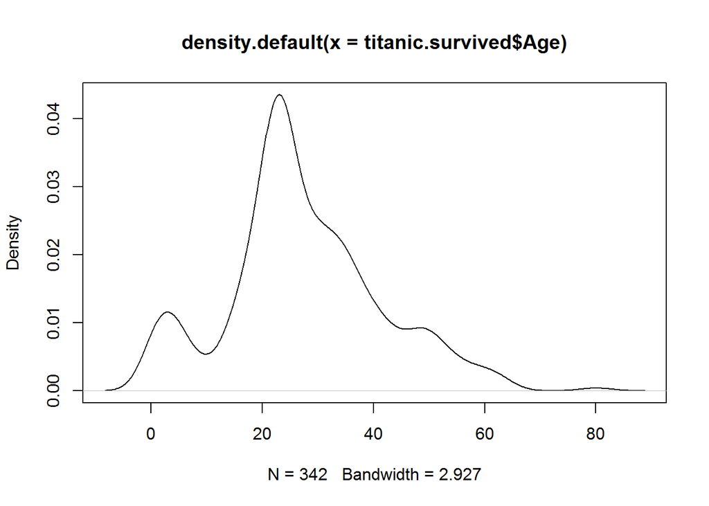

```r
plot(density(titanic.survived$Age))
```

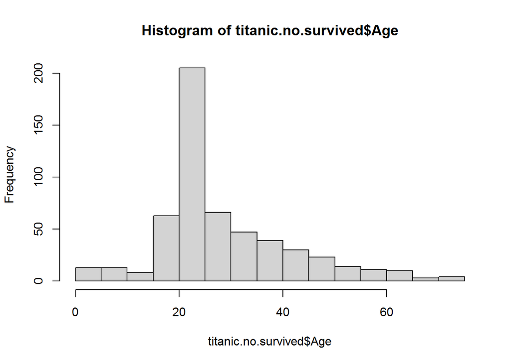

```r
hist(titanic.no.survived$Age)
```

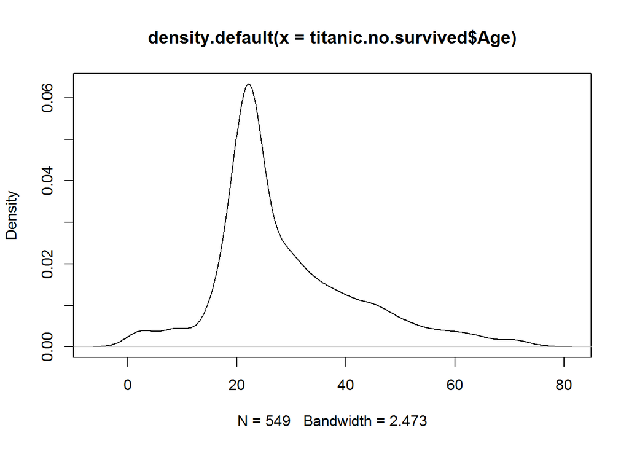

```r
plot(density(titanic.no.survived$Age))
```

Com es pot veure la primera es una distribució binomial i la segona no te una distribució normal. Es pot analitzar si la hipotesis es correcta a traves del gràfic del boxplot:

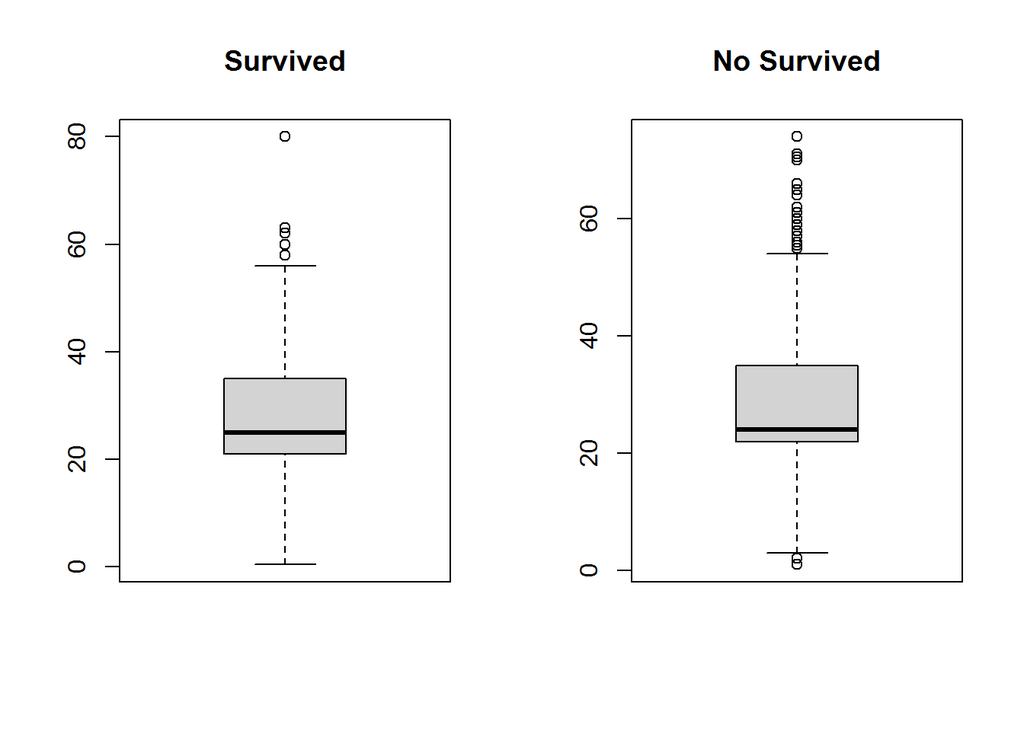

```r
par(mfrow=c(1,2))
boxplot(titanic.survived$Age, main="Survived")
boxplot(titanic.no.survived$Age, main="No Survived")
```

```r
par(mfrow=c(1,1))
```

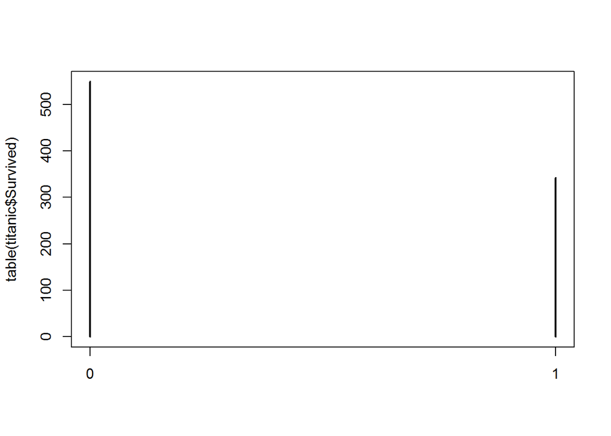

```r
plot(table(titanic$Survived))
```

```r
prop.table(table(titanic$Survived))
```

```
##
##         0         1
## 0.6161616 0.3838384
```

## 6 Resolució del problema

> A partir dels resultats obtinguts, quines són les conclusions? Els resultats permeten respondre al problema?

Aixi que acabar costa molt poder identificar les persones que poden sobrviure amb refenrencia a la hipotesis les persones joves tenen una posibilitat de viure i les persones que haguin comprat algun tipus de bitllet mes elevat.